# Exploration of Severe Weather Events in the United States between 1950 and 2011 and their effect on Population Health and the Economy

## Reproducible Research : Peer Assessment 2

### Data Processing

The data for this assignment come in the form of a comma-separated-value file compressed via the bzip2 algorithm to reduce its size. You can download the file from the link below:

[StormData](https://d396qusza40orc.cloudfront.net/repdata%2Fdata%2FStormData.csv.bz2)

First, we must read the data into R (Assumes the above file in your working directory)

```r
stormdata <- read.csv(bzfile("repdata-data-StormData.csv.bz2"))
cache=TRUE
```

After reading in the data, we check the dimensions and the first few rows.

```r
dim(stormdata)
```

```
## [1] 902297     37
```

```r
head(stormdata)
```

```
##   STATE__           BGN_DATE BGN_TIME TIME_ZONE COUNTY COUNTYNAME STATE
## 1       1  4/18/1950 0:00:00     0130       CST     97     MOBILE    AL
## 2       1  4/18/1950 0:00:00     0145       CST      3    BALDWIN    AL
## 3       1  2/20/1951 0:00:00     1600       CST     57    FAYETTE    AL
## 4       1   6/8/1951 0:00:00     0900       CST     89    MADISON    AL
## 5       1 11/15/1951 0:00:00     1500       CST     43    CULLMAN    AL
## 6       1 11/15/1951 0:00:00     2000       CST     77 LAUDERDALE    AL
##    EVTYPE BGN_RANGE BGN_AZI BGN_LOCATI END_DATE END_TIME COUNTY_END
## 1 TORNADO         0                                               0
## 2 TORNADO         0                                               0
## 3 TORNADO         0                                               0
## 4 TORNADO         0                                               0
## 5 TORNADO         0                                               0
## 6 TORNADO         0                                               0
##   COUNTYENDN END_RANGE END_AZI END_LOCATI LENGTH WIDTH F MAG FATALITIES
```

[output cut: 20 more lines]

The dataset has 902,297 rows and 37 columns.

To get more information about the columns we use the str function on the data

```r
str(stormdata)
```

```
## 'data.frame':    902297 obs. of  37 variables:
##  $ STATE__   : num  1 1 1 1 1 1 1 1 1 1 ...
##  $ BGN_DATE  : Factor w/ 16335 levels "1/1/1966 0:00:00",..: 6523 6523 4242 11116 2224 2224 2260 383 3980 3980 ...
##  $ BGN_TIME  : Factor w/ 3608 levels "00:00:00 AM",..: 272 287 2705 1683 2584 3186 242 1683 3186 3186 ...
##  $ TIME_ZONE : Factor w/ 22 levels "ADT","AKS","AST",..: 7 7 7 7 7 7 7 7 7 7 ...
##  $ COUNTY    : num  97 3 57 89 43 77 9 123 125 57 ...
##  $ COUNTYNAME: Factor w/ 29601 levels "","5NM E OF MACKINAC BRIDGE TO PRESQUE ISLE LT MI",..: 13513 1873 4598 10592 4372 10094 1973 23873 24418 4598 ...
##  $ STATE     : Factor w/ 72 levels "AK","AL","AM",..: 2 2 2 2 2 2 2 2 2 2 ...
##  $ EVTYPE    : Factor w/ 985 levels "   HIGH SURF ADVISORY",..: 834 834 834 834 834 834 834 834 834 834 ...
##  $ BGN_RANGE : num  0 0 0 0 0 0 0 0 0 0 ...
##  $ BGN_AZI   : Factor w/ 35 levels "","  N"," NW",..: 1 1 1 1 1 1 1 1 1 1 ...
##  $ BGN_LOCATI: Factor w/ 54429 levels "","- 1 N Albion",..: 1 1 1 1 1 1 1 1 1 1 ...
##  $ END_DATE  : Factor w/ 6663 levels "","1/1/1993 0:00:00",..: 1 1 1 1 1 1 1 1 1 1 ...
##  $ END_TIME  : Factor w/ 3647 levels ""," 0900CST",..: 1 1 1 1 1 1 1 1 1 1 ...
##  $ COUNTY_END: num  0 0 0 0 0 0 0 0 0 0 ...
```

[output cut: 23 more lines]

Our analysis focuses on the effects of severe weather events on population health and the economy so we will extract only the columns that are necessary. These columns are EVTYPE,INJURIES, FATALITIES, PROPDMG, CROPDMG, PROPDMGEXP, and CROPDMGEXP.

EVTYPE lists the severe weather event type.

INJURIES and FATALITIES are self explanatory and are numeric columns.

PROPDMG and CROPDMG are numeric values as well but to get their actual value we must multiply them by the value in the corresponding PROPDMGEXP and CROPDMGEXP fields.

First lets subset the data with the columns we are interested in:

```r
stormdatasubset<- stormdata[,c("EVTYPE", "INJURIES", "FATALITIES", "PROPDMG", "CROPDMG", "PROPDMGEXP", "CROPDMGEXP") ]
```

Our data subset now has 902297 rows and 7 columns.

```r
dim(stormdatasubset)
```

```
## [1] 902297      7
```

```r
head(stormdatasubset)
```

```
##    EVTYPE INJURIES FATALITIES PROPDMG CROPDMG PROPDMGEXP CROPDMGEXP
## 1 TORNADO       15          0    25.0       0          K
## 2 TORNADO        0          0     2.5       0          K
## 3 TORNADO        2          0    25.0       0          K
## 4 TORNADO        2          0     2.5       0          K
## 5 TORNADO        2          0     2.5       0          K
## 6 TORNADO        6          0     2.5       0          K
```

Since effects on population health include both FATALITIES and INJURIES, we will create a new column in the dataset called FATINJ which will sum both columns and display a total.

```r
stormdatasubset$FATINJ <- stormdatasubset$INJURIES + stormdatasubset$FATALITIES
```

Our dataset now has 8 columns:

```r
head(stormdatasubset)
```

```
##    EVTYPE INJURIES FATALITIES PROPDMG CROPDMG PROPDMGEXP CROPDMGEXP FATINJ
## 1 TORNADO       15          0    25.0       0          K                15
## 2 TORNADO        0          0     2.5       0          K                 0
## 3 TORNADO        2          0    25.0       0          K                 2
## 4 TORNADO        2          0     2.5       0          K                 2
## 5 TORNADO        2          0     2.5       0          K                 2
## 6 TORNADO        6          0     2.5       0          K                 6
```

Taking a closer look at the CROPDMGEXP and PROPDMGEXP columns we see that entries are not consistent and have many different values, so this requires cleaning.

```r
summary(stormdatasubset$PROPDMGEXP)
```

```
##             -      ?      +      0      1      2      3      4      5
## 465934      1      8      5    216     25     13      4      4     28
##      6      7      8      B      h      H      K      m      M
##      4      5      1     40      1      6 424665      7  11330
```

```r
summary(stormdatasubset$CROPDMGEXP)
```

```
##             ?      0      2      B      k      K      m      M
## 618413      7     19      1      9     21 281832      1   1994
```

We are only interested in the values H, K, M, B (which stands for hundered, thousand, million, and billion) We can assume the lowercase values are typos and convert them to upper case. We can disregard all other values. They are also a very small portion of the data.

```r
stormdatasubset$PROPDMGEXP <- toupper(stormdatasubset$PROPDMGEXP)
stormdatasubset$CROPDMGEXP <- toupper(stormdatasubset$CROPDMGEXP)
```

Now we make the logical substitutions so the columns can be multiplied(we assume that a blank space means the value is 1):

```r
stormdatasubset$PROPDMGEXP[stormdatasubset$PROPDMGEXP==""]<-"1"
stormdatasubset$PROPDMGEXP[stormdatasubset$PROPDMGEXP=="H"]<-"100"
stormdatasubset$PROPDMGEXP[stormdatasubset$PROPDMGEXP=="K"]<-"1000"
stormdatasubset$PROPDMGEXP[stormdatasubset$PROPDMGEXP=="M"]<-"1000000"
stormdatasubset$PROPDMGEXP[stormdatasubset$PROPDMGEXP=="B"]<-"1000000000"
```

Convert to numeric so column can be muliplied

```r
stormdatasubset$PROPDMGEXP<-as.numeric(stormdatasubset$PROPDMGEXP)
```

Repeat steps for CROPDMGEXP column

```r
stormdatasubset$CROPDMGEXP[stormdatasubset$CROPDMGEXP==""]<-"1"
stormdatasubset$CROPDMGEXP[stormdatasubset$CROPDMGEXP=="H"]<-"100"
stormdatasubset$CROPDMGEXP[stormdatasubset$CROPDMGEXP=="K"]<-"1000"
stormdatasubset$CROPDMGEXP[stormdatasubset$CROPDMGEXP=="M"]<-"1000000"
stormdatasubset$CROPDMGEXP[stormdatasubset$CROPDMGEXP=="B"]<-"1000000000"
```

Convert to numeric so column can be muliplied

```r
stormdatasubset$CROPDMGEXP<-as.numeric(stormdatasubset$CROPDMGEXP)
```

Muliply columns and create two new columns

```r
stormdatasubset$PROPTOTAL <- stormdatasubset$PROPDMG * stormdatasubset$PROPDMGEXP

stormdatasubset$CROPTOTAL <- stormdatasubset$CROPDMG * stormdatasubset$CROPDMGEXP
```

```r
stormdatasubset$ECONTOTAL <- stormdatasubset$CROPTOTAL * stormdatasubset$PROPTOTAL
```

Our data is now clean and organized, we can start looking at results.

## Results

Lets first look at the effect of severe weather events on population health. We will plot the total fatalities and injuries (FATINJ) by event type (EVTYPE).

```r
aggregatefatinj <- aggregate(stormdatasubset$FATINJ, list(stormdatasubset$EVTYPE), FUN = "sum", na.rm = TRUE)
```

Order the results in decreasing order and display the top ten events

```r
Tallypop <- head(aggregatefatinj[order(aggregatefatinj$x, decreasing = T), ], 10)
Tallypop
```

```
##               Group.1     x
## 834           TORNADO 96979
## 130    EXCESSIVE HEAT  8428
## 856         TSTM WIND  7461
## 170             FLOOD  7259
## 464         LIGHTNING  6046
## 275              HEAT  3037
## 153       FLASH FLOOD  2755
## 427         ICE STORM  2064
## 760 THUNDERSTORM WIND  1621
## 972      WINTER STORM  1527
```

Now we can plot the fatalites and injuries by event type.

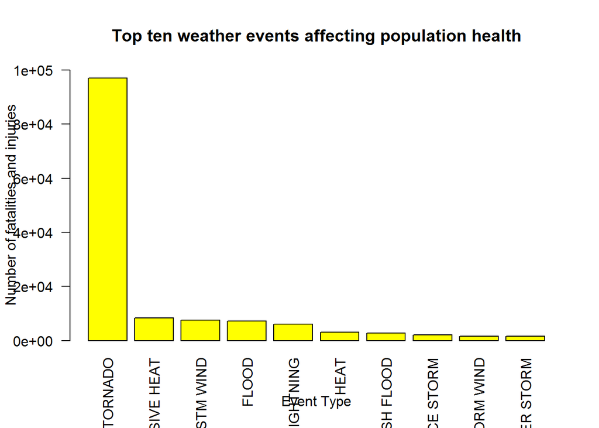

```r
barplot(Tallypop[1:10,2], names.arg=Tallypop[1:10,1], col = 47, main= "Top ten weather events affecting population health" ,ylab = "Number of fatalities and injuries", xlab = "Event Type", las=2, ylim = c(0,100000))
```

As we can see from the barplot, the event type which overwhelmingly effects population health the most is Tornado. A distant second is excessive heat.

Now lets look at the effect of severe weather events on the economy. First we will aggregate the ECONTOTAL column by event type.

```r
aggregateecontotal <- aggregate(stormdatasubset$ECONTOTAL, list(stormdatasubset$EVTYPE), FUN = "sum", na.rm = TRUE)
```

Order the results in decreasing order and display the top ten events.

```r
Econpop <- head(aggregateecontotal[order(aggregateecontotal$x, decreasing = T), ], 10)

Econpop
```

```
##               Group.1            x
## 590       RIVER FLOOD 2.500022e+19
## 411 HURRICANE/TYPHOON 1.116032e+19
## 170             FLOOD 4.033058e+18
## 402         HURRICANE 2.394127e+18
## 359         HIGH WIND 1.672191e+17
## 153       FLASH FLOOD 4.975846e+16
## 95            DROUGHT 1.434242e+16
## 957          WILDFIRE 1.252988e+16
## 848    TROPICAL STORM 1.129844e+16
## 244              HAIL 1.094568e+16
```

Now we can plot the economic consequences by event type.

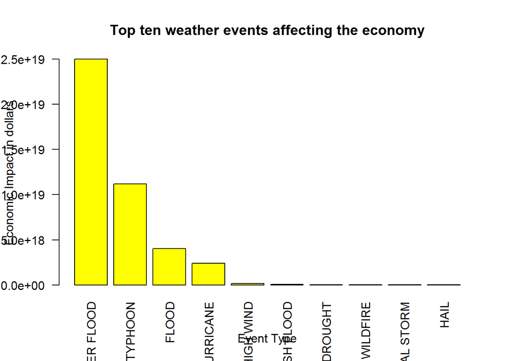

```r
barplot(Econpop[1:10,2], names.arg=Econpop[1:10,1], col = 47, main= "Top ten weather events affecting the economy" ,ylab = "Economic Impact in dollars", xlab = "Event Type", las=2)
```

## Conclusion and Summary

We initially set out to answer two questions: